# **Problem Statement**

# *Cluster 1 – High-Income Heavy Spenders*

**Observation**

These customers have a median income of about 69K, are typically born in the mid-1960s, and have minimal children at home. They are the highest spenders across almost all categories, especially wines (497 median units), meat (232), and gold products (45). They are highly active in store and catalog purchases and participate in campaigns at a higher rate than other clusters.

**Key Takeaway**

This is the core high-value customer base. Retention strategies, loyalty rewards, and premium offerings could further strengthen their lifetime value.

⸻

# *Cluster 2 – Ultra-High-Income Low Spenders*

**Observation**

**Key Takeaway**

Represents an underutilized premium segment. High-income but low-spend behavior signals an opportunity for personalized marketing and exclusive offers to unlock spending potential.

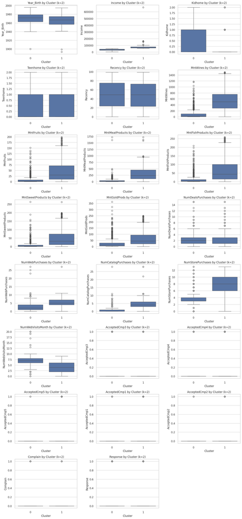

```
Cluster medians (k=2):
         Year_Birth   Income  Kidhome  Teenhome  Recency  MntWines  MntFruits  \
Cluster
0            1972.0  36588.5      1.0       0.0     49.0      27.0        3.0
1            1967.0  69514.0      0.0       1.0     49.0     505.0       30.0

         MntMeatProducts  MntFishProducts  MntSweetProducts  MntGoldProds  \
Cluster
0                   18.0              4.0               3.0          12.0
1                  239.0             43.5              31.5          45.0

         NumDealsPurchases  NumWebPurchases  NumCatalogPurchases  \
Cluster
0                      2.0              2.0                  1.0
1                      1.0              5.0                  4.0

         NumStorePurchases  NumWebVisitsMonth  AcceptedCmp3  AcceptedCmp4  \
Cluster
0                      3.0                7.0           0.0           0.0
1                      8.0                4.0           0.0           0.0

         AcceptedCmp5  AcceptedCmp1  AcceptedCmp2  Complain  Response
Cluster
0                 0.0           0.0           0.0       0.0       0.0
1                 0.0           0.0           0.0       0.0       0.0

Cluster means (k=2):
         Year_Birth    Income  Kidhome  Teenhome  Recency  MntWines  \
Cluster
0           1970.76  35475.98     0.71      0.49    49.20     89.14
1           1966.55  71417.32     0.14      0.53    48.67    546.72

         MntFruits  MntMeatProducts  MntFishProducts  MntSweetProducts  \
Cluster
0             7.62            40.89            11.83              8.19
1            47.28           311.06            66.15             48.64

         MntGoldProds  NumDealsPurchases  NumWebPurchases  \
Cluster
0               25.13               2.47             2.87
1               65.06               2.19             5.49

         NumCatalogPurchases  NumStorePurchases  NumWebVisitsMonth  \
Cluster
0                       0.93               3.75               6.60
1                       4.62               8.06               3.87

         AcceptedCmp3  AcceptedCmp4  AcceptedCmp5  AcceptedCmp1  AcceptedCmp2  \
Cluster
0                0.08          0.03          0.00          0.01          0.00
1                0.06          0.13          0.15          0.13          0.02

         Complain  Response
Cluster
0            0.01      0.11
1            0.01      0.20
```

```python
# numeric data
X = df.select_dtypes(include='number').dropna().copy()

# k = 2 (Silhouette Result)
k = 2

# fit KMeans and attach labels
km = KMeans(n_clusters=k, random_state=42, n_init=10)
labels = km.fit_predict(X)
X_prof = X.copy()
X_prof['Cluster'] = labels

# boxplots per feature by cluster
features = [c for c in X_prof.columns if c != 'Cluster']
cols = 3
rows = int(np.ceil(len(features)/cols))
fig, axes = plt.subplots(rows, cols, figsize=(5*cols, 4*rows))
axes = np.array(axes).reshape(-1)
for i, col in enumerate(features):
    sns.boxplot(x='Cluster', y=col, data=X_prof, ax=axes[i])
    axes[i].set_title(f'{col} by Cluster (k={k})')
for j in range(i+1, rows*cols):
    fig.delaxes(axes[j])
plt.tight_layout()
plt.show()

# summary stats to support detailed observations
print(f"\nCluster medians (k={k}):")
print(X_prof.groupby('Cluster')[features].median().round(2))
print(f"\nCluster means (k={k}):")
print(X_prof.groupby('Cluster')[features].mean().round(2))
```

# **Observation from Silhouette Method (k=2):**

# *Cluster 0 – Mid-Income Moderate Buyers*

**Observation**

This cluster’s median income is about 36K, with members generally born in the early 1970s. Most households have one child and no teenagers. They make moderate purchases—wines (27 median units) and meat (18) are the top categories, with low spending on other products. They tend to visit the website often (7 visits/month) but make relatively few store and catalog purchases. Campaign participation is minimal.

**Key Takeaway**

A stable mid-income group with consistent but moderate purchase activity. Strong potential for upselling and cross-category marketing, especially to convert frequent website visits into higher online purchase volumes.

⸻

# *Cluster 1 – High-Income Heavy Spenders*

**Observation**

This group has a median income of about 69K and members typically born in the mid-1960s. Households rarely have children but sometimes have teenagers. They are the highest spenders across nearly all categories, with particularly large purchases in wines (505 median units), meat (239), and gold products (45). They are active in store, catalog, and online purchasing channels and show higher acceptance rates for campaigns compared to Cluster 0.

**Key Takeaway**

Represents the premium, high-value customer base. High engagement across channels suggests strong loyalty—ideal candidates for exclusive promotions, loyalty rewards, and premium product launches to further increase spend and retention.

#### **Question 11**: Perform cluster profiling on the data using a barplot for the K-Means algorithm. Provide insights and key observations for each cluster based on the visual analysis.

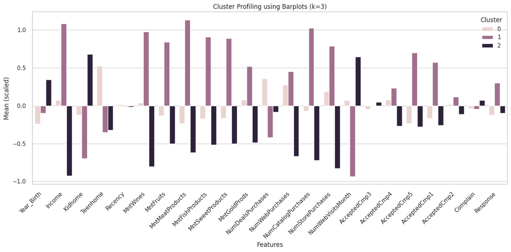

```python
# Write your code here

# From the Elow we identified K = 3
k = 3
features = X_prof.columns.drop('Cluster') if 'Cluster' in X_prof.columns else X_prof.columns  # adjust if needed

# 1) (Re)fit KMeans and ensure Cluster labels exist
km = KMeans(n_clusters=k, random_state=42)
labels = km.fit_predict(X_prof[features])
X_prof['Cluster'] = labels

# 2) Scale features for fair comparison in the barplot (does NOT change your original data)
scaler = StandardScaler()
X_scaled_for_plot = X_prof.copy()
X_scaled_for_plot[features] = scaler.fit_transform(X_scaled_for_plot[features])

# 3) Compute cluster means and melt for plotting
cluster_means = (
    X_scaled_for_plot.groupby('Cluster')[features]
    .mean()
    .reset_index()
    .melt(id_vars='Cluster', var_name='Feature', value_name='Mean_Value')
)

# 4) Barplot
plt.figure(figsize=(14, 7))
sns.barplot(
    data=cluster_means,
    x='Feature', y='Mean_Value',
    hue='Cluster',
    hue_order=sorted(cluster_means['Cluster'].unique())
)
plt.xticks(rotation=45, ha='right')
plt.title(f'Cluster Profiling using Barplots (k={k})')
plt.ylabel('Mean (scaled)')
plt.xlabel('Features')
plt.legend(title='Cluster')
plt.tight_layout()
plt.show()
```